# Assignment2

Yiheng Du

2022-10-31

Student ID: u7457260 Github Sharing: [The address of Github](https://github.com/DeweyYihengDu/assignment2)

# Introduction

## library the packages which will be used.

```r
library(tidyverse)
library(metafor)
library(orchaRd)
library(here)
library(pacman)
library(flextable)
```

## Read the data

```r
data1 <- read_csv(here('data', 'OA_activitydat_20190302_BIOL3207.csv'))
```

```
## ──────────────────────────────────────────────────────── Delimiter: "," chr
## (5): loc, species, treatment, size, comment dbl (4): ...1, animal_id, sl,
## activity
```

# Do the meta-analysis

## Analysis the data form Clark get the data of Mean, SD and M.

### Read the data and get the name of every fish.

```r
fish_name <- data1 %>% select(species) %>% unique()
```

### Calculate the data about the Mean, SD and N.

```r
tidydata <- function(i){
  control <- data1 %>%
    filter(species == i) %>%
    filter(treatment=="control") %>%
    select(activity) %>%
    drop_na()
  oa <- data1 %>%
    filter(species == i) %>%
    filter(treatment=="CO2") %>%
    select(activity) %>%
    drop_na()
  Species = i
  ctrl.sd = sd(control$activity)
  ctrl.mean=mean(control$activity)
  ctrl.n=nrow(control)
  oa.sd = sd(oa$activity)
  oa.mean=mean(oa$activity)
  oa.n=nrow(oa)
  data.frame(Species,ctrl.mean,ctrl.sd,ctrl.n, oa.mean, oa.sd, oa.n)
}

a=rbind(tidydata("ambon"),tidydata("lemon"),tidydata("chromis"),tidydata("acantho"),tidydata("humbug"),tidydata("whitedams"))
```

## Merge the summary statistics

```r
clark_paper_data <- read_csv(here("data","clark_paper_data.csv"))
clark_paper_data
```

```
## # A tibble: 1 × 15
##   Study Authors    Year …¹ Year …² Title Journal Pub y…³ 2017 …⁴ Avera…⁵ Effec…⁶
##   <chr> <chr>        <dbl>   <dbl> <chr> <chr>     <dbl>   <dbl>   <dbl> <chr>
## 1 a92   Clark et …    2020    2020 Ocea… Nature     69.5    41.6      45 Weak
## # … with 5 more variables: `Climate (FishBase)` <chr>,
## #   `Env cue/stimulus?` <chr>, `Cue/stimulus type` <lgl>,
## #   `Behavioural metric` <chr>, `Life stage` <chr>, and abbreviated variable
## #   names ¹`Year (online)`, ²`Year (print)`, ³`Pub year IF`, ⁴`2017 IF`,
## #   ⁵`Average n`, ⁶`Effect type`
```

```r
b = cbind(clark_paper_data,a)
```

## Merge the combined summary statistics and metadata from Clark et al. (2020) (output from 1 & 2) into the larger meta-analysis dataset

```r
ocean_meta_data <- read_csv(here("data","ocean_meta_data.csv"))
meta_data = rbind(b, ocean_meta_data)
```

Then, tidy the data and reneme some data.

```r
colnames(meta_data)[3] <- 'Year_online'
colnames(meta_data)[4] <- 'Year_print'
colnames(meta_data)[11] <- 'Climate'
colnames(meta_data)[15] <- 'Life_stage'
colnames(meta_data)[10] <- "Effect_type"
meta_data <- meta_data %>% mutate(residual = 1:n())
```

```r
head(meta_data)
```

```
##   Study     Authors Year_online Year_print
## 1   a92 Clark et al        2020       2020
## 2   a92 Clark et al        2020       2020
## 3   a92 Clark et al        2020       2020
## 4   a92 Clark et al        2020       2020
## 5   a92 Clark et al        2020       2020
## 6   a92 Clark et al        2020       2020
##                                                                    Title
## 1 Ocean acidification does not impair the behaviour of coral reef fishes
## 2 Ocean acidification does not impair the behaviour of coral reef fishes
## 3 Ocean acidification does not impair the behaviour of coral reef fishes
## 4 Ocean acidification does not impair the behaviour of coral reef fishes
## 5 Ocean acidification does not impair the behaviour of coral reef fishes
## 6 Ocean acidification does not impair the behaviour of coral reef fishes
##   Journal Pub year IF 2017 IF Average n Effect_type Climate Env cue/stimulus?
```

[output cut: 20 more lines]

# Start the meta analys

## Get the log response ration(LnRR)

```r
LnRR_data <- escalc(measure = "ROM",
             n1i=ctrl.n, n2i = oa.n, m1i = ctrl.mean,m2i = oa.mean,sd1i = ctrl.sd,sd2i = oa.sd,
             data=meta_data, var.names = c("LnRR", "v"))
```

## Correct meta-analytic model fitted to the data that controls for the sampling variance of lnRR.

```r
ss <- rma.mv(LnRR~1, V=v,data=LnRR_data,method = "REML",
             random = list(~1|Study, ~1|residual, ~1|Year_online, ~1|Climate,~1|Life_stage, ~1|Species,~1|Effect_type),
             dfs = "contain", test = "t")
summary(ss)
```

```
##
## Multivariate Meta-Analysis Model (k = 801; method: REML)
##
##     logLik    Deviance         AIC         BIC        AICc
## -1781.0788   3562.1576   3578.1576   3615.6345   3578.3397
##
## Variance Components:
##
##             estim    sqrt  nlvls  fixed       factor
## sigma^2.1  0.0000  0.0001     92     no        Study
## sigma^2.2  3.8821  1.9703    801     no     residual
## sigma^2.3  1.0738  1.0362     12     no  Year_online
## sigma^2.4  0.0118  0.1086      7     no      Climate
## sigma^2.5  0.0000  0.0000      4     no   Life_stage
## sigma^2.6  0.0829  0.2880     62     no      Species
## sigma^2.7  0.0000  0.0000      3     no  Effect_type
##
## Test for Heterogeneity:
## Q(df = 800) = 736089076.3936, p-val < .0001
##
## Model Results:
##
## estimate      se     tval  df    pval    ci.lb   ci.ub
##  -0.3717  0.3257  -1.1413   2  0.3720  -1.7728  1.0295
##
## ---
## Signif. codes:  0 '***' 0.001 '**' 0.01 '*' 0.05 '.' 0.1 ' ' 1
```

## The result

### 95% Confidence Intervals in this model

```r
a=predict(ss, transf = "transf=exp")
a
```

```
##
##     pred     se   ci.lb  ci.ub    pi.lb  pi.ub
##  -0.3717 0.3257 -1.7728 1.0295 -10.1423 9.3989
```

- The 95% confidence interval ranged from -1.7728457 to 1.0295139.
- In 95% of the probability cases, the true value is expected to fall from -1.7728457 to 1.0295139.
- In other words, if we were to repeat the experiment many times, 95% of the confidence intervals constructed would contain the true meta-analytic mean.

### Measures of heterogeneity in effect size estimates across studies

```r
i2_vals <- orchaRd::i2_ml(ss)

i2 <- tibble(type = firstup(gsub("I2_", "", names(i2_vals))), I2 = i2_vals)

flextable(i2) %>%
    align(part = "header", align = "center") %>%
    compose(part = "header", j = 1, value = as_paragraph(as_b("Type"))) %>%
    compose(part = "header", j = 2, value = as_paragraph(as_b("I"), as_b(as_sup("2")),
        as_b("(%)")))
```

| Type | I2(%) |
| --- | --- |
| Total | 99.99999991650206255 |
| Study | 0.00000023478957760 |
| Residual | 76.86442382874582790 |
| Year_online | 21.25990931677462115 |
| Climate | 0.23356851192436592 |
| Life_stage | 0.00000000095663147 |
| Species | 1.64209802324060328 |
| Effect_type | 0.00000000007043942 |

```r
predict(ss)
```

```
##
##     pred     se   ci.lb  ci.ub    pi.lb  pi.ub
##  -0.3717 0.3257 -1.7728 1.0295 -10.1423 9.3989
```

### The forest plot about the meta analysis

```r
M1 <- rma.mv(LnRR~1, V=v,data=LnRR_data,method = "REML",
             random = list(~1|Study, ~1|residual, ~1|Species, ~1|Year_online),
             dfs = "contain", test = "t")
```

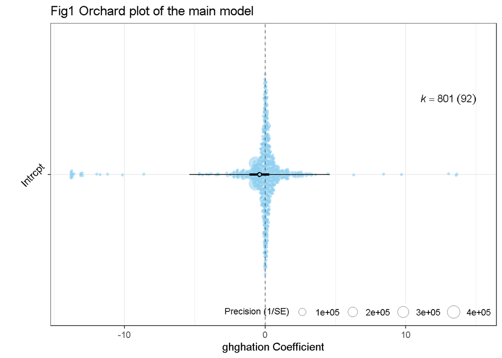

Figure 1: Orchard plot of the main model

```r
orchaRd::orchard_plot(M1, group = "Study", mod = "1", data = LnRR_data, xlab = "ghghation Coefficient",angle = 45) + labs(title = "Fig1 Orchard plot of the main model")
```

```r
M2Climate<- rma.mv(LnRR~Climate-1, V=v,data=LnRR_data,method = "REML",
             random = list(~1|Study, ~1|residual,  ~1|Year_online),
             dfs = "contain", test = "t")
```

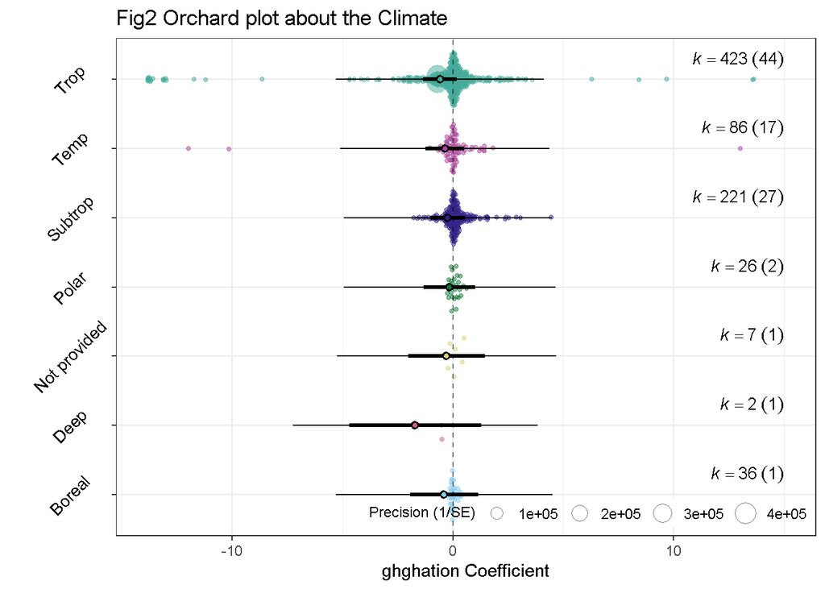

Figure 2: Orchard plot about the Climate

```r
orchaRd::orchard_plot(M2Climate, group = "Study", mod = "Climate", data = LnRR_data, xlab = "ghghation Coefficient",angle = 45)+labs(title="The forest plot of the model of climate") + labs(title = "Fig2 Orchard plot about the Climate")
```

```r
M3Life_stage<- rma.mv(LnRR~Life_stage-1, V=v,data=LnRR_data,method = "REML",
             random = list(~1|Study, ~1|residual,  ~1|Year_online),
             dfs = "contain", test = "t")
```

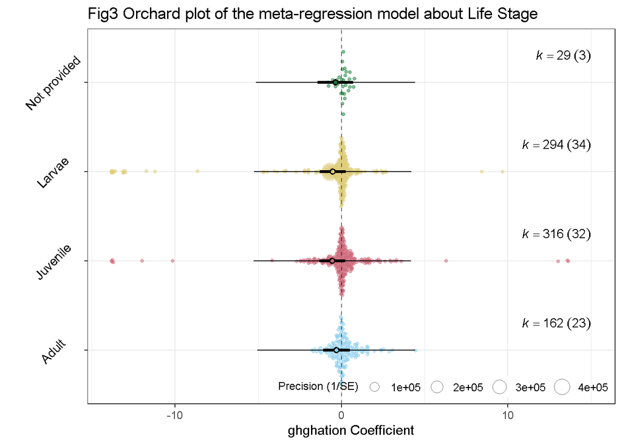

Figure 3: Orchard plot of the meta-regression model about Life Stage

```r
orchaRd::orchard_plot(M3Life_stage, group = "Study", mod = "Life_stage", data = LnRR_data, xlab = "ghghation Coefficient",angle = 45)+labs(title="Fig3 Orchard plot of the meta-regression model about Life Stage")
```

From the Fig3, the mean is a hollow circle in the middle and the 95% confidence interval is a short horizontal line thickened in the middle. `k` is the number of effect sizes and the number of studies are in brackets.

```r
M4Effect_type<- rma.mv(LnRR~Effect_type-1, V=v,data=LnRR_data,method = "REML",
             random = list(~1|Study, ~1|residual,  ~1|Year_online),
             dfs = "contain", test = "t")
```

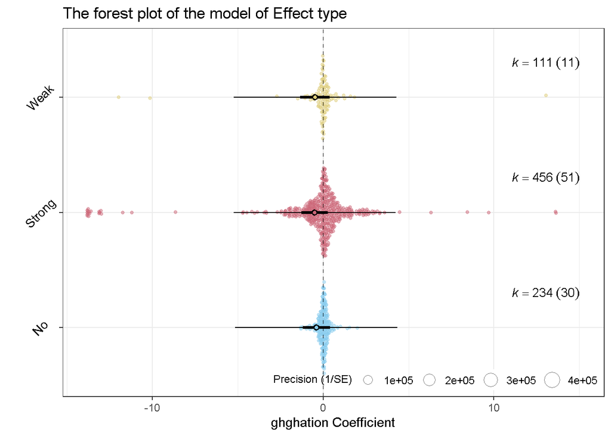

Figure 4: Orchard plot of the meta-regression model about effect type

```r
orchaRd::orchard_plot(M4Effect_type, group = "Study", mod = "Effect_type", data = LnRR_data, xlab = "ghghation Coefficient",angle = 45)+labs(title="The forest plot of the model of Effect type")
```

From the Fig4, the mean is a hollow circle in the middle and the 95% confidence interval is a short horizontal line thickened in the middle. `k` is the number of effect sizes and the number of studies are in brackets.